# Wine Set Analysis - In Class

Ron Neely - Rowan Data Mining 2 @ LMCO Fall 2018, Modified: 2018.10.07 (Lecture 3 class 2018.09.19)

Download wine sets.

Next build a neural network that predicts wine quality using the white wine set.

1. Don’t forget to normalize
2. use 50% of the data (randomly selected) for training and the remaining 50% for testing.
3. How accurate is the model?
4. Do it a few more times with a variety of hidden nodes. Note if you do hidden=(8, 4) for example it will create 2 hidden layers with the first having 8 hidden nodes and the next having 4 hidden nodes.
5. Feed the red wine data into your model. How accurately does the white wine model predict red wine quality?
6. If you finish early do k-folds or test in SVM or Randomforest

```python
%matplotlib inline
from IPython.display import display
import matplotlib.pyplot as plt
import seaborn as sns
import pandas as pd
import numpy as np
from sklearn import datasets
from sklearn.preprocessing import StandardScaler
from sklearn.model_selection import train_test_split

from sklearn.neural_network import MLPClassifier
from sklearn.ensemble import RandomForestClassifier
from sklearn.svm import SVC

from sklearn.metrics import classification_report,confusion_matrix
from sklearn.metrics import accuracy_score
from sklearn.model_selection import KFold

import sys
print(sys.version)
!pwd
!ls *.csv
```

```
3.6.6 |Anaconda custom (64-bit)| (default, Jun 28 2018, 11:27:44) [MSC v.1900 64 bit (AMD64)]
/c/Users/AFMS/r/rn/rw/dm2/lecture/03
winequality-red.csv
winequality-white.csv
```

## 1. Read data in to a pandas DataFrame and normalize

```python
## The inclass dataset is different from the standard wine dataset included with sklearn.
# def sklearn_to_yX(sklearn_dataset, scaler = None):
#     X = pd.DataFrame(sklearn_dataset.data, columns=sklearn_dataset.feature_names)
#     y = pd.Series(sklearn_dataset.target)
#     if scaler:
#         X[X.columns] = scaler.fit_transform(X[X.columns])
#     return y, X
#
# y, X = sklearn_to_yX(datasets.load_wine(), StandardScaler())

## Load the in-class datasets from disk and normalize them into one dataframe.
def load_yX(filename, sep=';'):
    df = pd.read_csv("winequality-white.csv", sep=';')
    y = df.iloc[:,-1]
    X = df.iloc[:,0:-1]
    return y, X

def peekprint_yX(y, X, head_count=3):
    print("Has any Nan: {}".format(y.isnull().values.any() or y.isnull().values.any()))
    print("y:{} {}; X:{}".format(y.shape, y.dtypes, X.shape))
    print(X.dtypes)
    #print("y: " , y.head(head_count))
    display(y.head(head_count))
    display(X.head(head_count))

yr, Xr = load_yX("winequality-red.csv")
Xr['red']=1
yw, Xw = load_yX("winequality-white.csv")
Xw['red']=0
y = pd.concat([yr, yw])
X = pd.concat([Xr, Xw])
scaler = StandardScaler()
X[X.columns[0:-1]] = scaler.fit_transform(X[X.columns[0:-1]])
peekprint_yX(y, X)
```

```
Has any Nan: False
y:(9796,) int64; X:(9796, 12)
fixed acidity           float64
volatile acidity        float64
citric acid             float64
residual sugar          float64
chlorides               float64
free sulfur dioxide     float64
total sulfur dioxide    float64
density                 float64
pH                      float64
sulphates               float64
alcohol                 float64
red                       int64
dtype: object
```

```
0    6
1    6
2    6
Name: quality, dtype: int64
```

|  | fixed acidity | volatile acidity | citric acid | residual sugar | chlorides | free sulfur dioxide | total sulfur dioxide | density | pH | sulphates | alcohol | red |
| --- | --- | --- | --- | --- | --- | --- | --- | --- | --- | --- | --- | --- |
| 0 | 0.172097 | -0.081770 | 0.213280 | 2.821349 | -0.035355 | 0.569932 | 0.744565 | 2.331512 | -1.246921 | -0.349184 | -1.393152 | 1 |
| 1 | -0.657501 | 0.215896 | 0.048001 | -0.944765 | 0.147747 | -1.253019 | -0.149685 | -0.009154 | 0.740029 | 0.001342 | -0.824276 | 1 |
| 2 | 1.475751 | 0.017452 | 0.543838 | 0.100282 | 0.193523 | -0.312141 | -0.973336 | 0.358665 | 0.475102 | -0.436816 | -0.336667 | 1 |

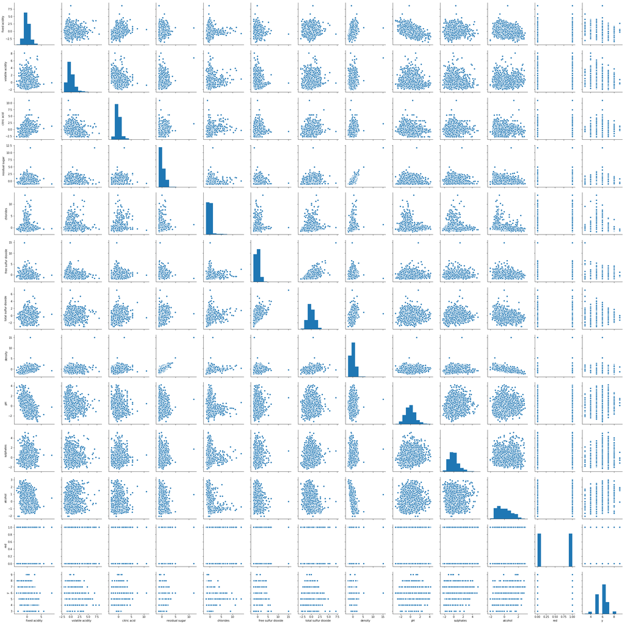

```python
df = X.copy()
df['y']=y
g = sns.pairplot(df)
g.savefig("wine_pairs.png")
```

Densitiy looks proportional to residual sugar inversely proportional to alcohol.  
Quality ranges from 3 to 9 on a scale of 1 to 10 with very few 3's or 9's.

```python
for i in range(3,10):
    print(i, y[y.values==i].count())
```

```
3 40
4 326
5 2914
6 4396
7 1760
8 350
9 10
```

```python
# Split the datasets back out to red and white
yr = y[X['red']!=0]
Xr = X[X['red']!=0].iloc[:,0:-1]
yw = y[X['red']==0]
Xw = X[X['red']==0].iloc[:,0:-1]
print(yr.shape, Xr.shape, yw.shape, Xw.shape)
Xw.head(1)
```

```
(4898,) (4898, 11) (4898,) (4898, 11)
```

|  | fixed acidity | volatile acidity | citric acid | residual sugar | chlorides | free sulfur dioxide | total sulfur dioxide | density | pH | sulphates | alcohol |
| --- | --- | --- | --- | --- | --- | --- | --- | --- | --- | --- | --- |
| 0 | 0.172097 | -0.08177 | 0.21328 | 2.821349 | -0.035355 | 0.569932 | 0.744565 | 2.331512 | -1.246921 | -0.349184 | -1.393152 |

Make a draftsman's plot to see the dataset.

## 2. use 50% of the data (randomly selected) for training and the remaining 50% for testing.

```python
X_train, X_test, y_train, y_test = train_test_split(Xw, yw, test_size=0.5)
print(X_train.shape, X_test.shape, y_train.shape, y_test.shape)
print(y_train.shape[0]/(y_train.shape[0]+y_test.shape[0]))
```

```
(2449, 11) (2449, 11) (2449,) (2449,)
0.5
```

## 3. How accurate is the model?

```python
nnm = MLPClassifier()
nnm.fit(X_train,y_train)
y_pred = nnm.predict(X_test)

def print_acc(y_actual, y_pred):
    print("       actual\n       +   -\npred+[[tp, fp]\ndict- [fn, tn]]")
    print(confusion_matrix(y_actual, y_pred), "\n")
    print("\n")
    print(classification_report(y_actual, y_pred))
    print(accuracy_score(y_actual, y_pred))

print_acc(y_test, y_pred)
```

```
       actual
       +   -
pred+[[tp, fp]
dict- [fn, tn]]
[[  2   1   0   7   1   0   0]
 [  1  11  46  21   2   0   0]
 [  2   6 427 280  11   1   0]
 [  0   3 216 763 118   3   0]
 [  0   0  20 255 153   3   0]
 [  0   0   1  54  39   0   0]
 [  0   0   0   1   1   0   0]]



             precision    recall  f1-score   support

          3       0.40      0.18      0.25        11
          4       0.52      0.14      0.22        81
          5       0.60      0.59      0.59       727
          6       0.55      0.69      0.61      1103
          7       0.47      0.35      0.40       431
          8       0.00      0.00      0.00        94
          9       0.00      0.00      0.00         2

avg / total       0.53      0.55      0.53      2449

0.5536953858717844
```

## 4. Do it a few more times with a variety of hidden nodes. Note if you do hidden=(8, 4) for example it will create 2 hidden layers with the first having 8 hidden nodes and the next having 4 hidden nodes.

```python
print(nnm)
```

```
MLPClassifier(activation='relu', alpha=0.0001, batch_size='auto', beta_1=0.9,
       beta_2=0.999, early_stopping=False, epsilon=1e-08,
       hidden_layer_sizes=(100,), learning_rate='constant',
       learning_rate_init=0.001, max_iter=200, momentum=0.9,
       nesterovs_momentum=True, power_t=0.5, random_state=None,
       shuffle=True, solver='adam', tol=0.0001, validation_fraction=0.1,
       verbose=False, warm_start=False)
```

Looks like above it used a hidden layer of (100,0). Perhaps this is a single hidden layer with a width of 100. Lets try a few different iterations of hidden layers and see how accurate they are. There are 7 quality categories, so use "7" in the mix.

```python
lyrs = [(100,), (7,1) ,(8,4), (7,49,7), (21,7), (7,14)]
for c in lyrs:
    print(c)
    nn = MLPClassifier(hidden_layer_sizes=c)
    nn.fit(X_train,y_train)
    y_p = nn.predict(X_test)
    print(accuracy_score(y_test, y_p))
    print(classification_report(y_test, y_p))
```

```
(100,)
```

```
0.5516537362188648
             precision    recall  f1-score   support

          3       0.33      0.18      0.24        11
          4       0.53      0.12      0.20        81
          5       0.60      0.60      0.60       727
          6       0.56      0.66      0.61      1103
          7       0.46      0.39      0.42       431
          8       0.14      0.01      0.02        94
          9       0.00      0.00      0.00         2

avg / total       0.53      0.55      0.53      2449

(7, 1)
0.5218456512862393
             precision    recall  f1-score   support

          3       0.00      0.00      0.00        11
          4       0.00      0.00      0.00        81
          5       0.57      0.43      0.49       727
          6       0.51      0.80      0.62      1103
          7       0.50      0.19      0.28       431
          8       0.00      0.00      0.00        94
          9       0.00      0.00      0.00         2

avg / total       0.49      0.52      0.47      2449

(8, 4)
0.5394038383013475
             precision    recall  f1-score   support

          3       0.00      0.00      0.00        11
          4       1.00      0.01      0.02        81
          5       0.58      0.57      0.57       727
          6       0.54      0.68      0.60      1103
          7       0.47      0.36      0.41       431
          8       0.00      0.00      0.00        94
          9       0.00      0.00      0.00         2

avg / total       0.53      0.54      0.51      2449
```

[output cut: 27 more lines]

```
avg / total       0.51      0.54      0.51      2449

(7, 14)
0.5471621069824418
             precision    recall  f1-score   support

          3       0.00      0.00      0.00        11
          4       0.00      0.00      0.00        81
          5       0.57      0.58      0.58       727
          6       0.54      0.72      0.62      1103
          7       0.51      0.30      0.38       431
          8       0.50      0.02      0.04        94
          9       0.00      0.00      0.00         2

avg / total       0.52      0.55      0.52      2449
```

None of these predict as well as (100,). They were all only slightly better than random.

## 5. Feed the red wine data into your model. How accurately does the white wine model predict red wine quality?

```python
yr_pred = nnm.predict(Xr)
print_acc(yr, yr_pred)
```

```
       actual
       +   -
pred+[[tp, fp]
dict- [fn, tn]]
[[   4    1    4   10    1    0    0]
 [   1   31   87   41    3    0    0]
 [   2   10  917  507   20    1    0]
 [   0    4  359 1632  200    3    0]
 [   0    0   38  482  353    7    0]
 [   0    0    3   97   62   13    0]
 [   0    0    0    2    3    0    0]]



             precision    recall  f1-score   support

          3       0.57      0.20      0.30        20
          4       0.67      0.19      0.30       163
          5       0.65      0.63      0.64      1457
          6       0.59      0.74      0.66      2198
          7       0.55      0.40      0.46       880
          8       0.54      0.07      0.13       175
          9       0.00      0.00      0.00         5

avg / total       0.60      0.60      0.58      4898

0.6022866476112699
```

## 6. If you finish early do k-folds or test in SVM or Randomforest

Let's look at RandomForest to see what features are most imortant.

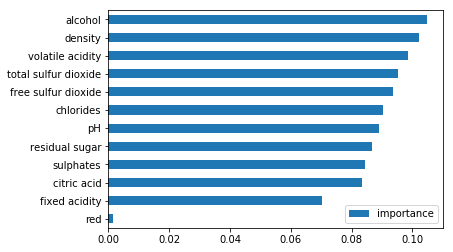

```python
m = RandomForestClassifier()
m.fit(X,y)
dff = pd.DataFrame(m.feature_importances_, columns=["importance"], index=X.columns.values)
dff = dff.sort_values(by='importance', ascending=True)
dff.plot(kind='barh')
```